# Operation Analytics

Jasmine Brown

11/10/2019

The First step in for any project is to install and load the necessary packages by declaring the libraries. The plyr package is to be used to select the variables in the clean data and the tidy verse for most of the other functions. Tidyverse is considered the swiss knife because of its unlimited capabilities. All packages used in the data wrangling process and the statistics are loaded into the console.

```r
library(tseries)
library(forecast)
library(dplyr)
library(zoo)
library(rio)
library(tidyverse)
```

To begin the cleaning process, we take a peek at the working directory with the getwd() function. If the working directory is not set to read the files, then the working directory has to be changed. The working directory is confirmed, and the data is imported

```r
setwd("~/Desktop/Project")
datax <-read.csv("df.csv")
datax <- select(datax, -c(X))
```

The as.date function formatted the dates to get them ready for the time series. These functions also take the date from character format. The glimpse function provides more concise information regarding the data set. A glimpse of the data set is called to determine the type of variables and ensure that the data set is correct.

```r
date <- as.Date(datax$date, "%m/%d/%y")
X<-(datax)
glimpse(X)
```

```
## Observations: 8,760
## Variables: 13
## $ date                          <fct> 1/1/18, 1/1/18, 1/1/18, 1/1/18, 1/…
## $ Time                          <fct> 1:00, 2:00, 3:00, 4:00, 5:00, 6:00…
## $ Heating.Electric.KWH          <int> 0, 0, 0, 0, 0, 0, 0, 0, 0, 0, 0, 0…
## $ Heating.Gas.KWH               <dbl> 1.5140609, 1.7416395, 2.0040508, 2…
## $ Cooling.Electricity.KWH       <dbl> 0, 0, 0, 0, 0, 0, 0, 0, 0, 0, 0, 0…
## $ Electricity.HVAC.KWH          <dbl> 0.039128765, 0.044963292, 0.051603…
## $ Gen.Int.LightsElectricity.KWH <dbl> 0.15401948, 0.08984473, 0.06417480…
## $ Gen.Ext.LightsElectricity.KWH <dbl> 0.03317990, 0.01935494, 0.01382495…
## $ Appl.Int.EquipElectricity.KWH <dbl> 0.09294292, 0.07618578, 0.06232649…
## $ Misc.Int.EquipElectricity.KWH <dbl> 0.4060349, 0.3738512, 0.3695167, 0…
## $ Water.Heat.SystemElectric.KWH <dbl> 0.15880347, 0.09808441, 0.08144175…
## $ Total.use.hr.KWH              <dbl> 2.398170, 2.443924, 2.646939, 2.68…
## $ Monthly.Sum                   <dbl> 7332.401, NA, NA, NA, NA, NA, NA, …
```

This portion of the code creates a time series for the variable of total usage for each hour — the total usage of each system. The clean count column creates a clean version of the variable I created to make sure I am working with useful data.

```r
time <- ts(X[,c("Total.use.hr.KWH")])
X$clean_count = tsclean(time)
```

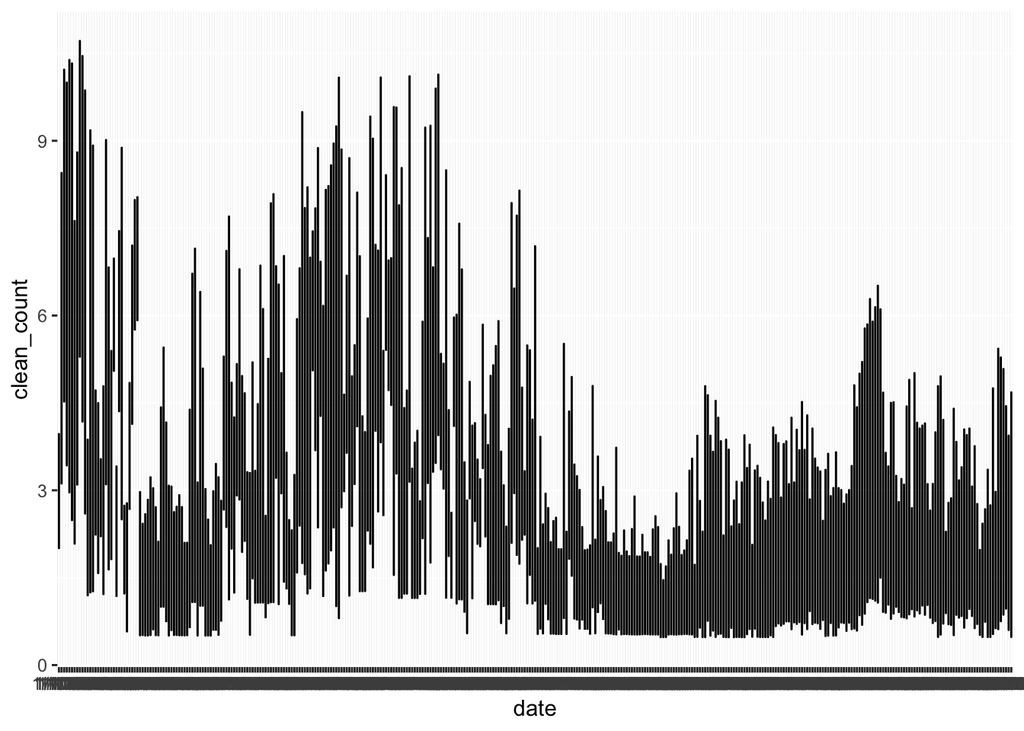

```r
ggplot()+ geom_line(data = X, aes(x =date, y=clean_count)) + ylab("clean_count")
```

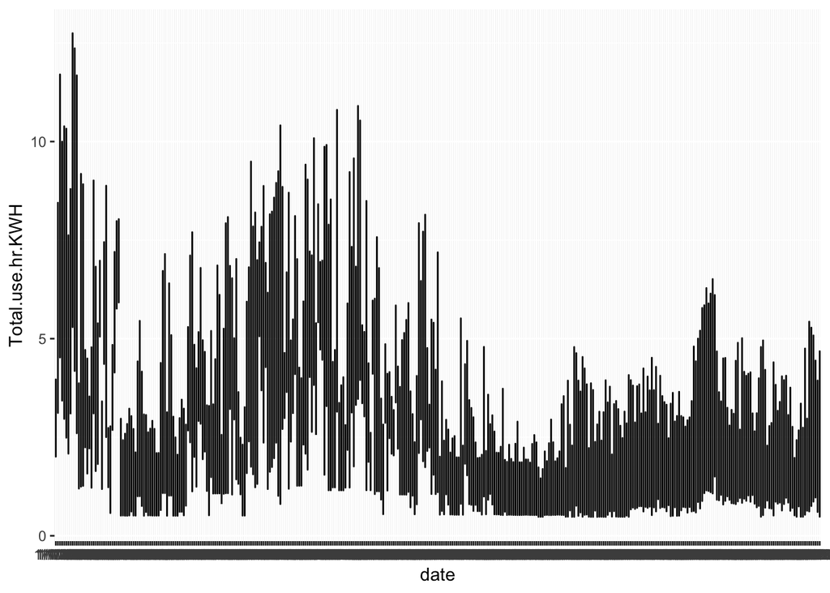

```r
ggplot()+ geom_line(data = X, aes(x =date, y=Total.use.hr.KWH)) + ylab("Total.use.hr.KWH")
```

This function creates a column for the weekly moving average of total usage and the monthly moving average of the total usage where I use a formula to multiply by the number of hours in a week and the number of hours in a month to get the order. It also inputs the average in as an outlier for the NA’s. A moving average can smooth out the noise of random outliers and emphasize long-term trends.

```r
#outlier missing data,
X$count_wa = ma(X$Total.use.hr.KWH, order = 168)
X$cont_Ma = ma(X$Total.use.hr.KWH, order = 720)
summary(X)
```

```
##       date           Time      Heating.Electric.KWH Heating.Gas.KWH
##  1/1/18 :  24   0:00   : 365   Min.   :0            Min.   : 0.000
##  1/10/18:  24   1:00   : 365   1st Qu.:0            1st Qu.: 0.000
##  1/11/18:  24   10:00  : 365   Median :0            Median : 0.000
##  1/12/18:  24   11:00  : 365   Mean   :0            Mean   : 1.153
##  1/13/18:  24   12:00  : 365   3rd Qu.:0            3rd Qu.: 1.869
##  1/14/18:  24   13:00  : 365   Max.   :0            Max.   :11.013
##  (Other):8616   (Other):6570
##  Cooling.Electricity.KWH Electricity.HVAC.KWH
##  Min.   :0.0000          Min.   :0.000000
##  1st Qu.:0.0000          1st Qu.:0.003751
##  Median :0.0000          Median :0.069937
##  Mean   :0.1525          Mean   :0.225380
##  3rd Qu.:0.1597          3rd Qu.:0.218113
##  Max.   :2.5497          Max.   :3.134967
##
##  Gen.Int.LightsElectricity.KWH Gen.Ext.LightsElectricity.KWH
##  Min.   :0.0000                Min.   :0.00000
##  1st Qu.:0.0622                1st Qu.:0.01340
##  Median :0.1088                Median :0.02345
##  Mean   :0.1957                Mean   :0.04215
##  3rd Qu.:0.2788                3rd Qu.:0.06007
##  Max.   :0.7967                Max.   :0.17162
##
##  Appl.Int.EquipElectricity.KWH Misc.Int.EquipElectricity.KWH
##  Min.   :0.0000                Min.   :0.0000
##  1st Qu.:0.1045                1st Qu.:0.3096
##  Median :0.2759                Median :0.3561
##  Mean   :0.2436                Mean   :0.3909
##  3rd Qu.:0.3468                3rd Qu.:0.4746
##  Max.   :0.4840                Max.   :0.6719
##
##  Water.Heat.SystemElectric.KWH Total.use.hr.KWH   Monthly.Sum
##  Min.   :0.0000                Min.   : 0.4776   Min.   :1872
##  1st Qu.:0.1874                1st Qu.: 1.2852   1st Qu.:2588
##  Median :0.3377                Median : 2.1650   Median :3200
##  Mean   :0.3381                Mean   : 2.7420   Mean   :4002
##  3rd Qu.:0.4683                3rd Qu.: 3.6676   3rd Qu.:4849
##  Max.   :0.8833                Max.   :12.7481   Max.   :7332
##                                                  NA's   :8748
##   clean_count         count_wa        cont_Ma
##  Min.   : 0.4776   Min.   :1.062   Min.   :1.243
##  1st Qu.: 1.2852   1st Qu.:1.718   1st Qu.:1.741
##  Median : 2.1650   Median :2.190   Median :2.130
##  Mean   : 2.7389   Mean   :2.734   Mean   :2.564
##  3rd Qu.: 3.6676   3rd Qu.:3.508   3rd Qu.:3.305
##  Max.   :10.7135   Max.   :6.821   Max.   :5.605
##                    NA's   :168     NA's   :720
```

```r
X2 <- replace(X, TRUE, lapply(X, na.aggregate))
summary(X2)
```

```
##       date           Time      Heating.Electric.KWH Heating.Gas.KWH
##  1/1/18 :  24   0:00   : 365   Min.   :0            Min.   : 0.000
##  1/10/18:  24   1:00   : 365   1st Qu.:0            1st Qu.: 0.000
##  1/11/18:  24   10:00  : 365   Median :0            Median : 0.000
##  1/12/18:  24   11:00  : 365   Mean   :0            Mean   : 1.153
##  1/13/18:  24   12:00  : 365   3rd Qu.:0            3rd Qu.: 1.869
##  1/14/18:  24   13:00  : 365   Max.   :0            Max.   :11.013
##  (Other):8616   (Other):6570
##  Cooling.Electricity.KWH Electricity.HVAC.KWH
##  Min.   :0.0000          Min.   :0.000000
##  1st Qu.:0.0000          1st Qu.:0.003751
##  Median :0.0000          Median :0.069937
##  Mean   :0.1525          Mean   :0.225380
##  3rd Qu.:0.1597          3rd Qu.:0.218113
##  Max.   :2.5497          Max.   :3.134967
##
##  Gen.Int.LightsElectricity.KWH Gen.Ext.LightsElectricity.KWH
##  Min.   :0.0000                Min.   :0.00000
##  1st Qu.:0.0622                1st Qu.:0.01340
##  Median :0.1088                Median :0.02345
##  Mean   :0.1957                Mean   :0.04215
##  3rd Qu.:0.2788                3rd Qu.:0.06007
##  Max.   :0.7967                Max.   :0.17162
##
##  Appl.Int.EquipElectricity.KWH Misc.Int.EquipElectricity.KWH
##  Min.   :0.0000                Min.   :0.0000
##  1st Qu.:0.1045                1st Qu.:0.3096
##  Median :0.2759                Median :0.3561
##  Mean   :0.2436                Mean   :0.3909
##  3rd Qu.:0.3468                3rd Qu.:0.4746
##  Max.   :0.4840                Max.   :0.6719
##
##  Water.Heat.SystemElectric.KWH Total.use.hr.KWH   Monthly.Sum
##  Min.   :0.0000                Min.   : 0.4776   Min.   :1872
##  1st Qu.:0.1874                1st Qu.: 1.2852   1st Qu.:4002
##  Median :0.3377                Median : 2.1650   Median :4002
##  Mean   :0.3381                Mean   : 2.7420   Mean   :4002
##  3rd Qu.:0.4683                3rd Qu.: 3.6676   3rd Qu.:4002
##  Max.   :0.8833                Max.   :12.7481   Max.   :7332
##
##   clean_count         count_wa        cont_Ma
##  Min.   : 0.4776   Min.   :1.062   Min.   :1.243
##  1st Qu.: 1.2852   1st Qu.:1.732   1st Qu.:1.785
##  Median : 2.1650   Median :2.234   Median :2.262
##  Mean   : 2.7389   Mean   :2.734   Mean   :2.564
##  3rd Qu.: 3.6676   3rd Qu.:3.447   3rd Qu.:2.998
##  Max.   :10.7135   Max.   :6.821   Max.   :5.605
##
```

These two GGplot are the plots of the total uses with the weekly moving aver and the monthly moving average on both data sets. We can conclude during January, November, and December the most electricity is being used. Instead of that during the summer month, we would naturally think that more eclectic is used because of bills fluctuate. We moved in the mean of the columns to fill in for the missing data

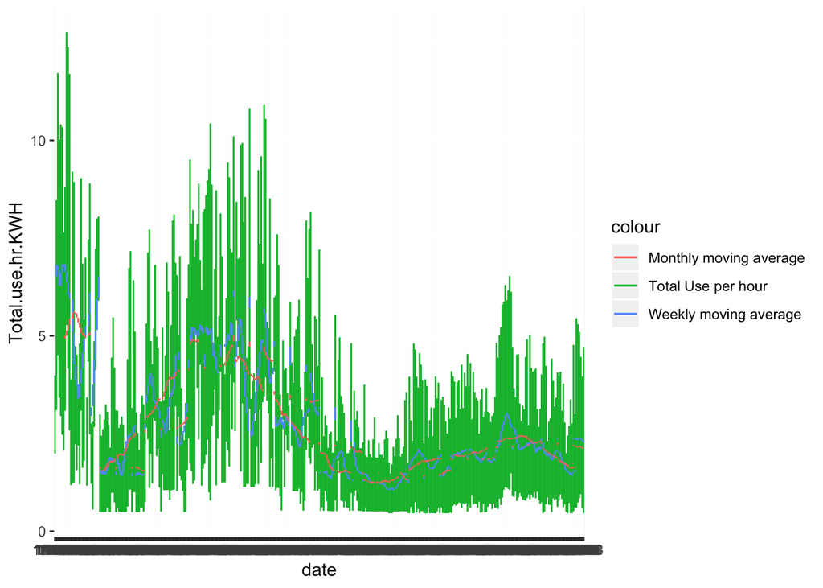

```r
ggplot() +
  geom_line(data = X, aes(x = date, y = Total.use.hr.KWH, colour ="Total Use per hour "))  +
  geom_line( data = X, aes(x = date, y = count_wa, colour ="Weekly moving average")) +
  geom_line(data = X, aes(x = date, y = cont_Ma, colour ="Monthly moving average"))
```

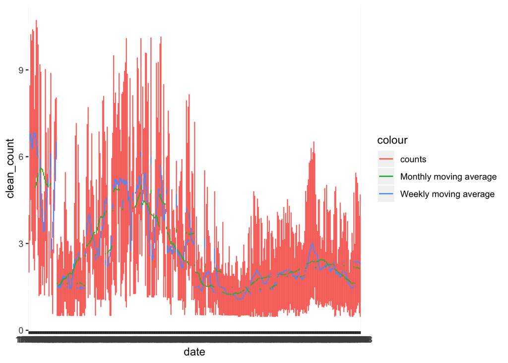

```r
ggplot() +
  geom_line(data = X2, aes(x = date, y = clean_count, colour ="counts"))  +
  geom_line(data = X2, aes(x = date, y = count_wa, colour ="Weekly moving average")) +
  geom_line(data = X2, aes(x = date, y = cont_Ma, colour ="Monthly moving average"))
```

The next plots were with the variables heating gas kwh and general int lights kwh. As the heating gas increase, the usage of general int lights starts a decrease. The ggplot function was used to also create a graph of the heating gas with the dates, and from January to April it shows a negative linear relationship, and it evens out during the summer months; then, in October there is a positive linear relationship where the usage increase until December.

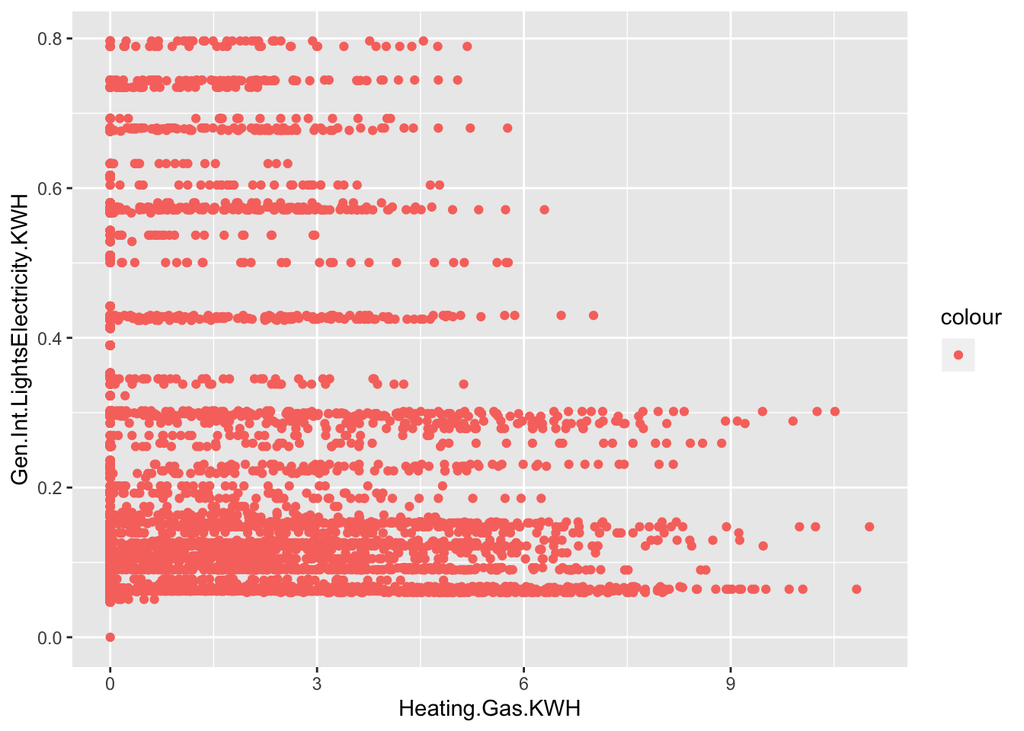

```r
#Create a scatter plot for "Heating Gas" and "Generl int lighting".
ggplot(X, aes(x =Heating.Gas.KWH , y =Gen.Int.LightsElectricity.KWH,col="")) +
  geom_point()
```

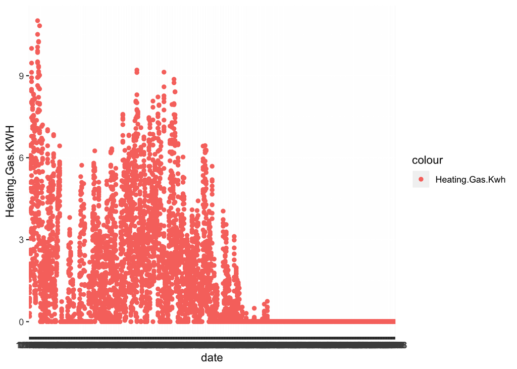

```r
ggplot(X, aes(x =date , y =Heating.Gas.KWH, col="Heating.Gas.Kwh")) +
  geom_point()
```

I also did a line plot on the dates of the heating ventilating and air condition usage. The results conclude that the peak is being used at the end of August. Usage begins to rise in May and decreases in October, becoming almost none from November until January.

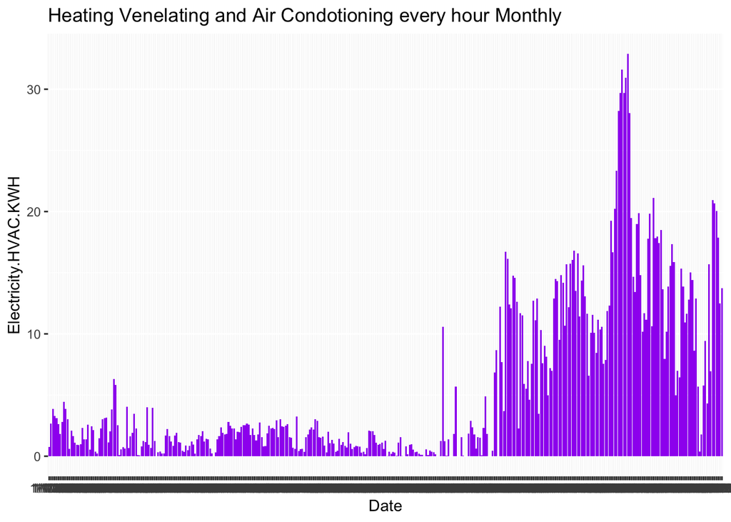

```r
ggplot(data = X, aes(x = date, y =Electricity.HVAC.KWH )) +
      geom_bar(stat = "identity", fill = "purple") +
      labs(title = "Heating Venelating and Air Condotioning every hour Monthly",  x = "Date", y = "Electricity.HVAC.KWH")
```

Statistical Analysis Now that it’s time for the decomposition of the data for in or to get ready for our forecasting model. Decomposing the data means taking seasonality, Trend, and cycle into account. This removes seasonality is a characteristic of a time series in which the data experiences regular and predictable changes that recur every calendar year. Any predictable fluctuation or pattern that recurs or repeats over one year is said to be seasonal. the seasonality, but I don’t have any n the date because of seasonality. We still decomposed because we can see the plot of the trends and the randomness of the data that can’t be accounted for over time. Count ma is a time series on the total use per hour. The frequency is over a quarterly period of the year, so I used the 24 hours in daytime 7-day times 12-week period to get the quarterly frequency.

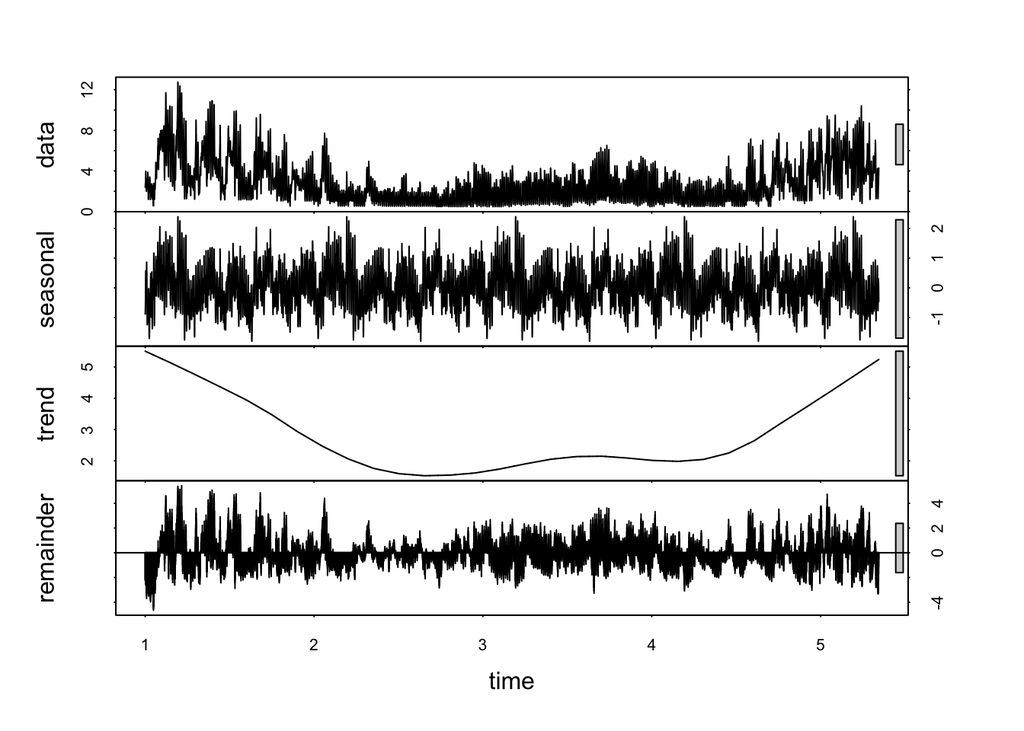

```r
count_ma <- ts(na.omit(X2$Total.use.hr.KWH),frequency = 2016)
decomp = stl(count_ma, "periodic")
deseasonal_cnt <- seasadj(decomp)
plot(decomp)
```

The test for permanent variance is the (ADF) augmented dick fuller test. A p-value less .05 indicates the data set is stationary. If your is not statutory, you can’t move on in the modeling. The ACF and pacf is the autocorrelation and partial autocorrelation between a series and its lag. A “lag” is a fixed amount of passing the time. The kth lag is the period that happened “k” time points before time. If our data wasn’t stationary, we could do a different test for the seasonal adjustment. Proving a stationary data set is critical when predicting. It shows that the mean and the variance are the same throughout the whole year or time series.

```r
adf.test(count_ma, alternative ="stationary")
```

```
##
##  Augmented Dickey-Fuller Test
##
## data:  count_ma
## Dickey-Fuller = -3.7621, Lag order = 20, p-value = 0.02081
## alternative hypothesis: stationary
```

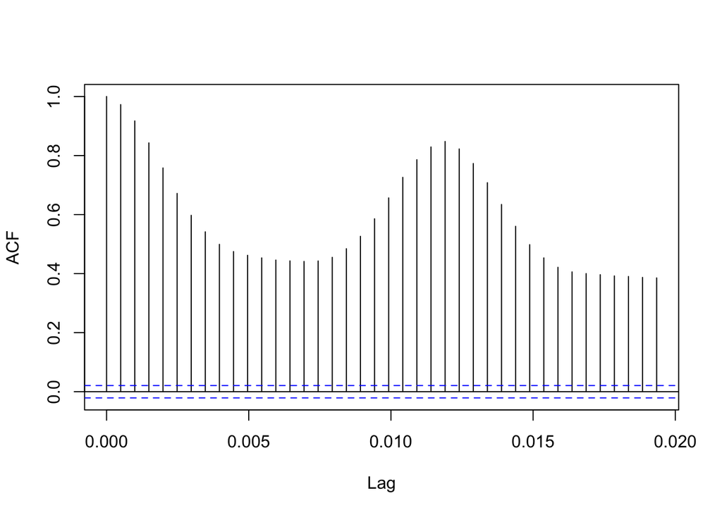

```r
acf(count_ma,main="")
```

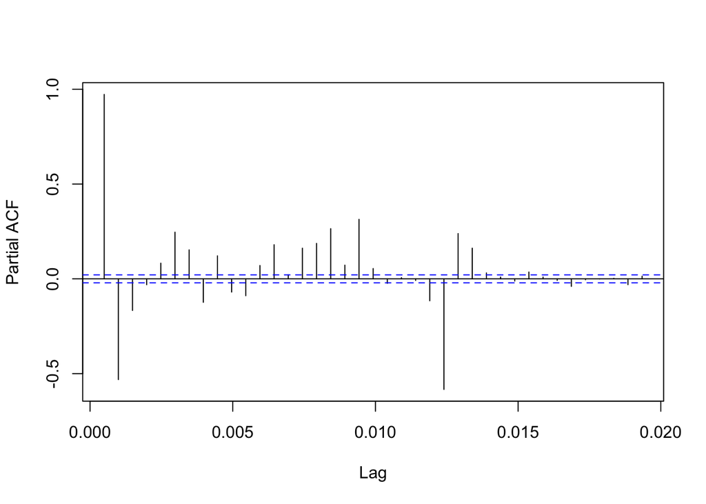

```r
pacf(count_ma,main="")
```

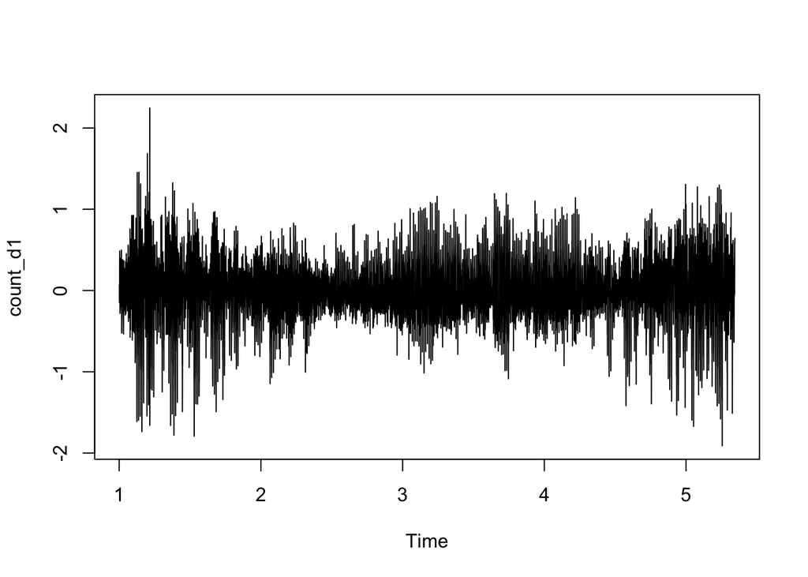

```r
count_d1 =diff(deseasonal_cnt, differences = 1)
plot(count_d1)
```

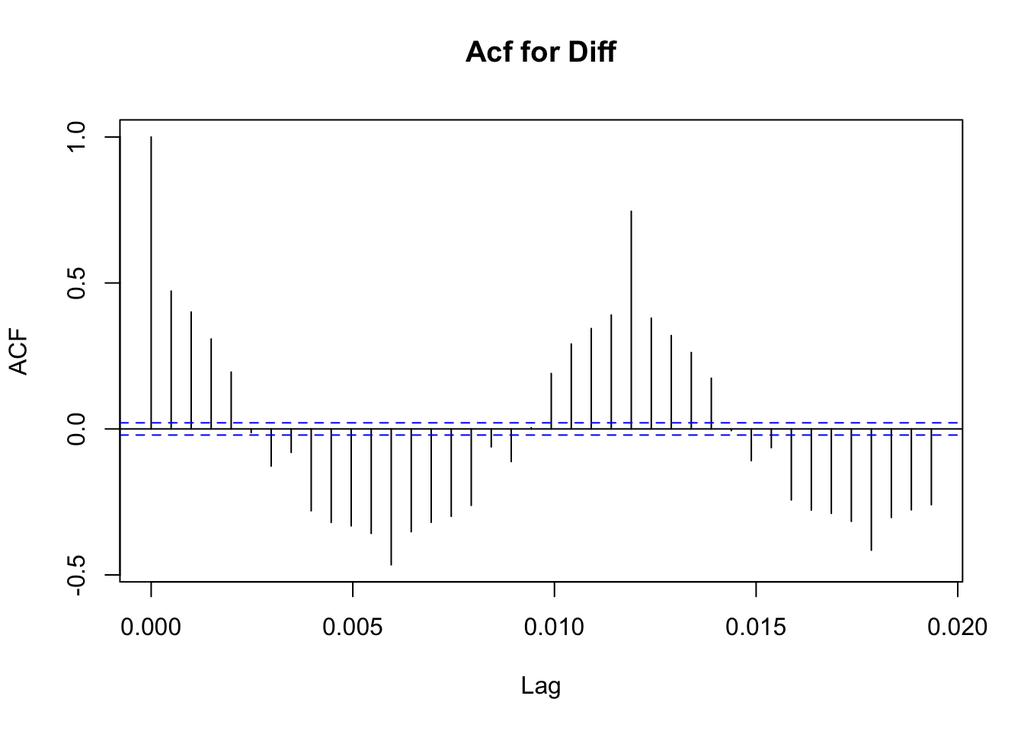

```r
acf(count_d1,main="Acf for Diff")
```

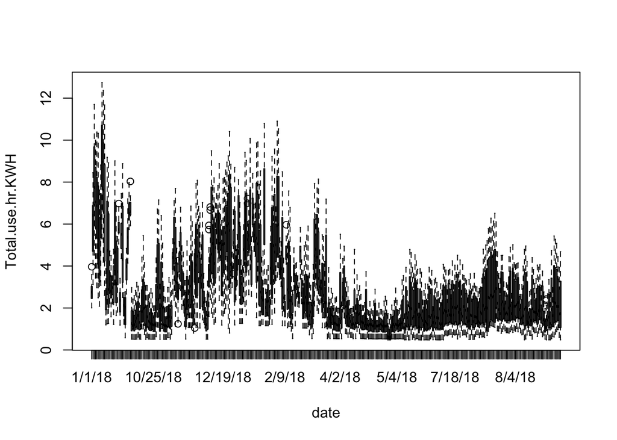

```r
library(WDI)
plot(data =X2,Total.use.hr.KWH~date)
```

```r
library(forecast)
#get auto pdq values
model<-auto.arima(count_ma,seasonal = FALSE)
model
```

```
## Series: count_ma
## ARIMA(2,1,3)
##
## Coefficients:
##          ar1      ar2      ma1     ma2     ma3
##       1.6988  -0.9628  -1.3803  0.5984  0.1874
## s.e.  0.0044   0.0043   0.0110  0.0161  0.0100
##
## sigma^2 estimated as 0.127:  log likelihood=-3390.66
## AIC=6793.32   AICc=6793.33   BIC=6835.79
```

```r
predict(model,n.ahead =8760,se.fit = T )
```

[output not shown]

[output cut: 2708 more lines]

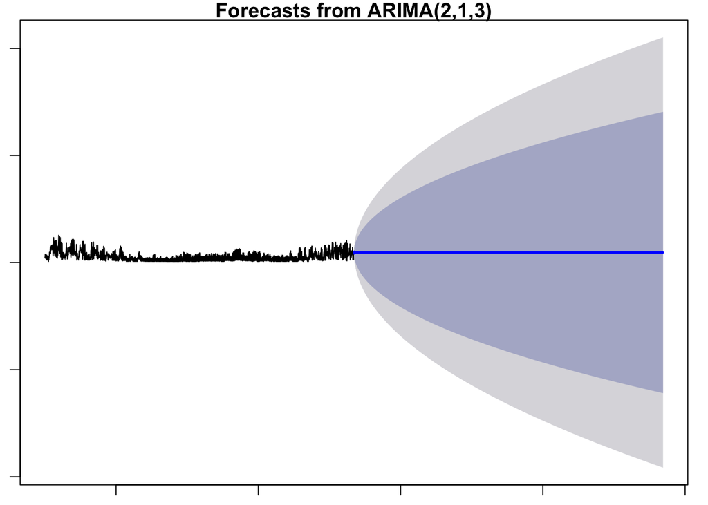

```r
TUForecast <- forecast(object =model,h=8760 )
par(mar=c(1,1,1,1))
plot(TUForecast)
```

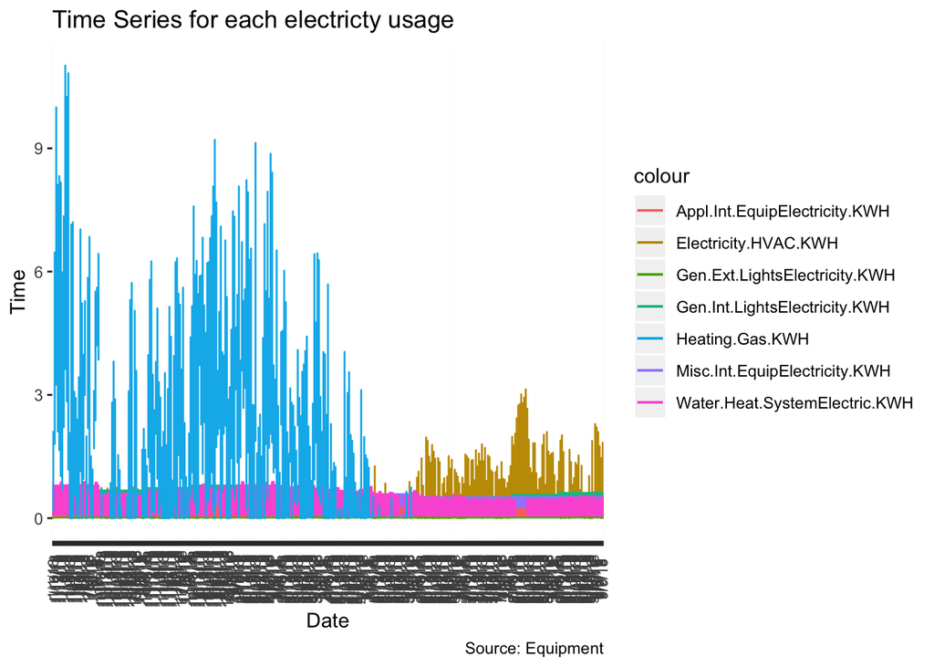

```r
ggplot(X2, aes(x=date,y=Time))+ geom_line(aes(y=Electricity.HVAC.KWH, col="Electricity.HVAC.KWH"))+
  geom_line(aes(y=Gen.Int.LightsElectricity.KWH, col="Gen.Int.LightsElectricity.KWH"))+
  geom_line(aes(y=Gen.Ext.LightsElectricity.KWH, col="Gen.Ext.LightsElectricity.KWH"))+
  geom_line(aes(y=Appl.Int.EquipElectricity.KWH, col="Appl.Int.EquipElectricity.KWH"))+
  geom_line(aes(y=Misc.Int.EquipElectricity.KWH, col="Misc.Int.EquipElectricity.KWH"))+
  geom_line(aes(y=Water.Heat.SystemElectric.KWH, col="Water.Heat.SystemElectric.KWH"))+
  geom_line(aes(y=Heating.Gas.KWH, col="Heating.Gas.KWH"))+
  labs(title="Time Series for each electricty usage",
       caption="Source: Equipment", y="Time", x="Date") +theme(axis.text.x = element_text(angle = 90, vjust=0.5, size = 8),  # rotate x axis text
        panel.grid.minor = element_blank())
```